# Lab1- 8969152 - Univariate-Linear-Regression

## **Practical Lab 1: Univariate Linear Regression on the California Housing Prices Dataset**

### **1. OBJECTIVE:**

In this lab, we will work on the California Housing Prices dataset to analyze the correlations between the median house value (dependent variable) and various independent variables, including median income, population, and the number of households. We will implement univariate linear regression models to examine how each of these factors influences the median house value and evaluate the model's performance based on key metrics.

```python
import numpy as np
import pandas as pd
import seaborn as sns
import matplotlib.pyplot as plt
from sklearn.model_selection import train_test_split
from sklearn.linear_model import LinearRegression
from sklearn.metrics import mean_squared_error, mean_absolute_error
```

## **2. Obtain the Data and Load the file into pandas dataframe**

**Source:** Downloaded from [Kaggle California Housing Prices](https://www.kaggle.com/datasets/camnugent/california-housing-prices/data)

```python
housing_df = pd.read_csv('housing.csv')

housing_df.head(2)
```

|  | longitude | latitude | housing_median_age | total_rooms | total_bedrooms | population | households | median_income | median_house_value | ocean_proximity |
| --- | --- | --- | --- | --- | --- | --- | --- | --- | --- | --- |
| 0 | -122.23 | 37.88 | 41.0 | 880.0 | 129.0 | 322.0 | 126.0 | 8.3252 | 452600.0 | NEAR BAY |
| 1 | -122.22 | 37.86 | 21.0 | 7099.0 | 1106.0 | 2401.0 | 1138.0 | 8.3014 | 358500.0 | NEAR BAY |

## **3. Exploratory Data Analysis (EDA)**

### **3.1 Exploring statistics**

```python
housing_df.describe()
```

|  | longitude | latitude | housing_median_age | total_rooms | total_bedrooms | population | households | median_income | median_house_value |
| --- | --- | --- | --- | --- | --- | --- | --- | --- | --- |
| count | 20640.000000 | 20640.000000 | 20640.000000 | 20640.000000 | 20433.000000 | 20640.000000 | 20640.000000 | 20640.000000 | 20640.000000 |
| mean | -119.569704 | 35.631861 | 28.639486 | 2635.763081 | 537.870553 | 1425.476744 | 499.539680 | 3.870671 | 206855.816909 |
| std | 2.003532 | 2.135952 | 12.585558 | 2181.615252 | 421.385070 | 1132.462122 | 382.329753 | 1.899822 | 115395.615874 |
| min | -124.350000 | 32.540000 | 1.000000 | 2.000000 | 1.000000 | 3.000000 | 1.000000 | 0.499900 | 14999.000000 |
| 25% | -121.800000 | 33.930000 | 18.000000 | 1447.750000 | 296.000000 | 787.000000 | 280.000000 | 2.563400 | 119600.000000 |
| 50% | -118.490000 | 34.260000 | 29.000000 | 2127.000000 | 435.000000 | 1166.000000 | 409.000000 | 3.534800 | 179700.000000 |
| 75% | -118.010000 | 37.710000 | 37.000000 | 3148.000000 | 647.000000 | 1725.000000 | 605.000000 | 4.743250 | 264725.000000 |
| max | -114.310000 | 41.950000 | 52.000000 | 39320.000000 | 6445.000000 | 35682.000000 | 6082.000000 | 15.000100 | 500001.000000 |

```python
housing_df.isnull().sum()
```

```
longitude               0
latitude                0
housing_median_age      0
total_rooms             0
total_bedrooms        207
population              0
households              0
median_income           0
median_house_value      0
ocean_proximity         0
dtype: int64
```

**Observations:** The dataset consisting of **20640 records** exhibits a wide range of values, particularly in total rooms, population, and median house value, suggesting significant variability in housing conditions. The median income has a right-skewed distribution, as indicated by the high maximum value (15.0001) compared to the mean (3.87), implying a few high-income households significantly influence the distribution.

There is also **207** null values in the total_bedrooms which means for 207/20640 houses we do not know the count of total bedrooms. but since that isn't in our list of independent variables used to analyze the median house value, we don't take any action on it

### **3.2 Scatterplots**

Since we are going to work on median_house_value, let's explore how they behave with respect to the independent variables

1. Median House Value vs Median Income
2. Median House Value vs Population
3. Median House Value vs Number of Households

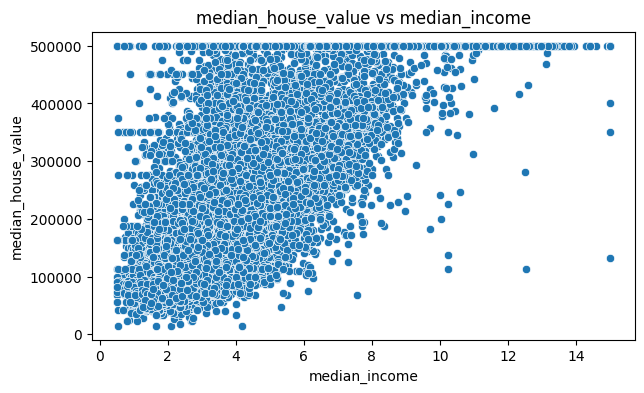

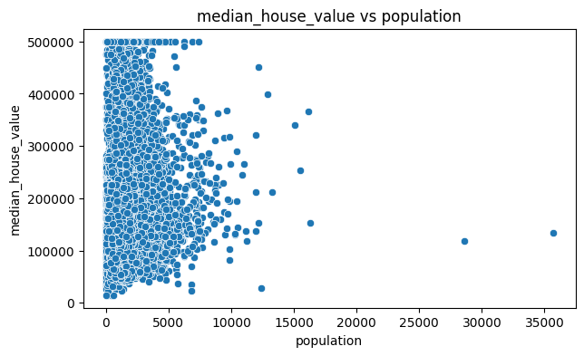

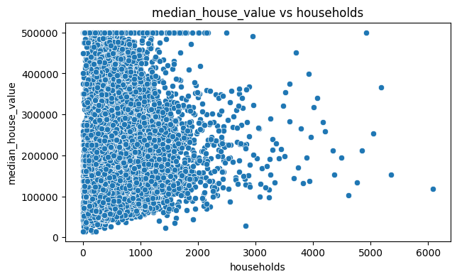

```python
independent_var = ["median_income", "population", "households"]

for i in independent_var:
    plt.figure(figsize=(7,4))
    sns.scatterplot(x=housing_df[i], y=housing_df["median_house_value"])
    plt.title(f"median_house_value vs {i}")
    plt.show()
```

**Observations / Interpretations:**

**Median House Value vs Median Income:** A significant number of house values appear to be capped at the upper limit of around 500,000. This indicates a possible imposed ceiling on recorded values, meaning the true relationship at higher income levels might be distorted.

**Median House Value vs. Population:** There is no clear linear relationship, with high dispersion and possible data capping at 500,000. Larger populations do not consistently correlate with higher house values.

**Median House Value vs. Households:** The relationship appears weak, with values clustered at the upper limit, suggesting that household count is not a strong predictor of house value.

```python
housing_processed = housing_df[housing_df.median_house_value != 500001]
```

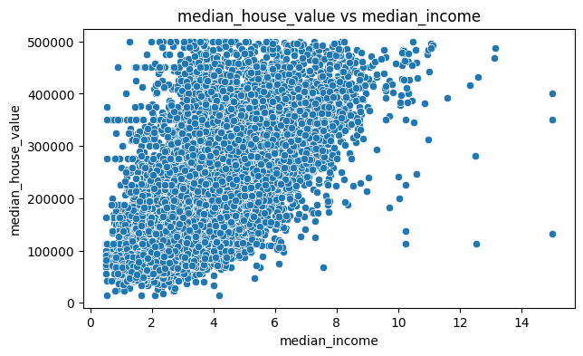

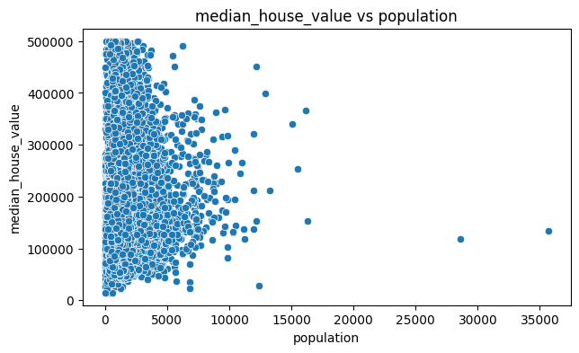

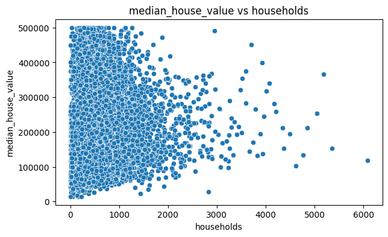

```python
for i in independent_var:
    plt.figure(figsize=(7,4))
    sns.scatterplot(x=housing_processed[i], y=housing_processed["median_house_value"])
    plt.title(f"median_house_value vs {i}")
    plt.show()
```

**Post processing inferences:**

After processing the data, We can see from the graph that there is a positive correlation between median income and median house value, indicating that higher income levels generally correspond to higher house values. However, the relationship is not perfectly linear, and there are some outliers and a possible upper limit on house prices.

### 3.3 **Variable Description:**

**median_house_value:** this variable represents the median price of houses in an area with values ranging from **$14,999 to $500,001.** The dataset appears to be capped at **500,000** potentially effecting our accuracy due to ceiling affect so we took care of it by filtering out rows with **values != 500001**

**population:** The total number of residents in a given area, with a wide range from **3 to 35,682**. The mean population is **1,425**, indicating that most areas have a relatively small number of residents.

**households:** The number of housing units occupied by families or individuals in a given area, ranging from **1 to 6,082.** The mean is **499**, suggesting that most neighborhoods contain a few hundred households.

## **4. Linear Regression models and 6. Regression Line Plot**

### **Train Test Split**

```python
train_size = int(len(housing_processed) * 0.90)
train = housing_processed[:train_size]
test = housing_processed[train_size:]
```

### **Model Fitting and Line :**

In this block we fit the model with three separate Linear Regression model for the 3 independent variables:

median_income

population

households  
Then using the model to predict (y_predict), we plot the prediction line in the scatterplots

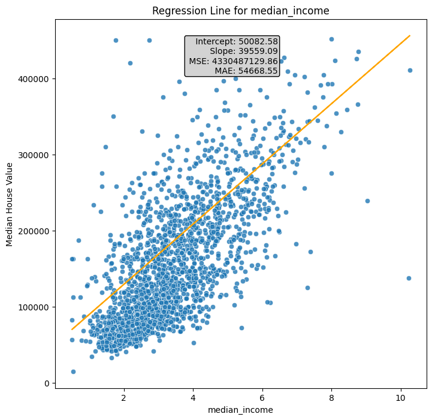

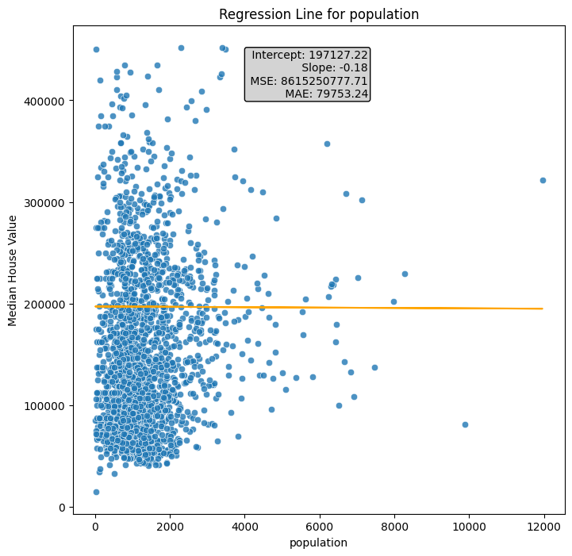

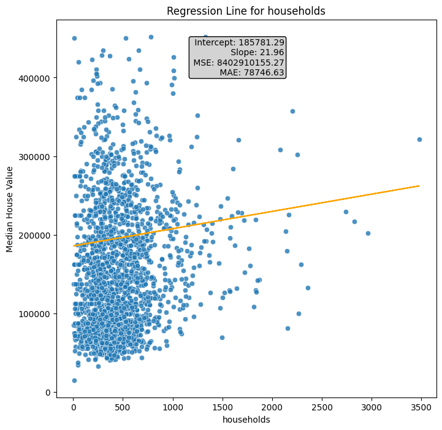

```python
Results = {}
for i in independent_var:
    model = LinearRegression()
    model.fit(X=train[[i]], y=train[["median_house_value"]])
    y_predict = model.predict(test[[i]])

    mse = mean_squared_error(test["median_house_value"], y_predict)
    mae = mean_absolute_error(test["median_house_value"], y_predict)
    Results[i]= { "intercept": model.intercept_.item(),
                  "slope": model.coef_[0],
                    "MSE": mse,
                    "MAE": mae
    }
    slope = Results[i]["slope"][0]
    plt.figure(figsize=(8,8))
    sns.scatterplot(x=test[i], y=test["median_house_value"], alpha=0.8)
    plt.plot(test[[i]], y_predict, color='orange')
    plt.title(f"Regression Line for {i}")
    plt.xlabel(i)
    plt.ylabel("Median House Value")
    plt.text(0.6,0.95,f" Intercept: {Results[i]["intercept"]:.2f}\n Slope: {slope:.2f}\n MSE: {mse:.2f}\n MAE: {mae:.2f}",transform=plt.gca().transAxes, fontsize=10,
         verticalalignment='top',horizontalalignment="right", bbox=dict(boxstyle='round,pad=0.2', edgecolor='black', facecolor='lightgrey'))

    plt.show()
```

## **5. Results**

```python
result_df=pd.DataFrame(Results)

result_df
```

|  | median_income | population | households |
| --- | --- | --- | --- |
| intercept | 50082.575041 | 197127.216225 | 185781.28846 |
| slope | [39559.094206699374] | [-0.1825129121979652] | [21.9638432372088] |
| MSE | 4330487129.856249 | 8615250777.707321 | 8402910155.271983 |
| MAE | 54668.547437 | 79753.243697 | 78746.630765 |

## **7. CONCLUSION**

1. Median Income (median_income) is the best predictor model out of the three, here is why:
   - Lowest Mean Square Error
   - Lowest Mean Average Error
   - Best line fit
2. Number of households (households) shows very weak relationship but it is still slightly better than population
3. Population (population) is the weakest among the three showing no correlation at all with highest MAE and MSE